# Quality Control mRNA arrays

Margalida Torrens Mas

9 de desembre, 2024

# Introducción

Este trabajo tiene como objetivo explorar los cambios tempranos en los perfiles de expresión génica asociados con el desarrollo del cáncer colorrectal (CCR), que puedan ayudar en un futuro a identificar marcadores que optimicen los programas actuales de cribado. Concretamente, se pretende analizar la expresión génica diferencial entre distintos estadios de la enfermedad, representados por muestras control sin enfermedad, muestras de adenomas de alto grado con probabilidad de avanzar a neoplasia, y muestras de CCR. El RNA usado para este análisis proviene de vesículas extracelulares extraídas del aspirado intestinal obtenido durante colonoscopias.

# Control de calidad

En este apartado se analiza la calidad de los datos de partida, tanto antes como después del proceso de normalización. En este apartado se describe el control de calidad aplicado a los datos de mRNA.

## Lectura de datos

Se analizan los datos de los microarrays de mRNA de 3 muestras correspondientes a cáncer colorrectal, 3 correspondientes a adenomas de alto grado, y 2 controles, ya que en el anterior análisis de calidad la muestra `Healthy3` era identificada como outlier.

```r
cel_files <- list.celfiles(params$raw_data_dir, full.names = T)
cel_files <- cel_files[-length(cel_files)]

samples <- read.AnnotatedDataFrame(file.path(params$raw_data_dir, "msamples.csv"), header=TRUE, row.names=1, sep=";")
samples <- samples[-nrow(samples), ]

raw_data <- read.celfiles(cel_files, pkgname="pd.clariom.s.human", phenoData = samples)
```

```
## Reading in : C:/Users/Lidat/Desktop/Màster Bioinformàtica i Bioestadística UOC/TFM/mdata/AR1.CEL
## Reading in : C:/Users/Lidat/Desktop/Màster Bioinformàtica i Bioestadística UOC/TFM/mdata/AR2.CEL
## Reading in : C:/Users/Lidat/Desktop/Màster Bioinformàtica i Bioestadística UOC/TFM/mdata/AR3.CEL
## Reading in : C:/Users/Lidat/Desktop/Màster Bioinformàtica i Bioestadística UOC/TFM/mdata/CCR1.CEL
## Reading in : C:/Users/Lidat/Desktop/Màster Bioinformàtica i Bioestadística UOC/TFM/mdata/CCR2.CEL
## Reading in : C:/Users/Lidat/Desktop/Màster Bioinformàtica i Bioestadística UOC/TFM/mdata/CCR3.CEL
## Reading in : C:/Users/Lidat/Desktop/Màster Bioinformàtica i Bioestadística UOC/TFM/mdata/CTRL1.CEL
## Reading in : C:/Users/Lidat/Desktop/Màster Bioinformàtica i Bioestadística UOC/TFM/mdata/CTRL2.CEL
```

```r
rownames(pData(raw_data)) <- samples@data$ShortName
colnames(raw_data) <- rownames(pData(raw_data))

head(raw_data) #check
```

```
## ExpressionFeatureSet (storageMode: lockedEnvironment)
## assayData: 6 features, 8 samples
##   element names: exprs
## protocolData
##   rowNames: Lesion1 Lesion2 ... Healthy2 (8 total)
##   varLabels: exprs dates
##   varMetadata: labelDescription channel
## phenoData
##   rowNames: Lesion1 Lesion2 ... Healthy2 (8 total)
##   varLabels: Group ShortName
##   varMetadata: labelDescription channel
## featureData: none
## experimentData: use 'experimentData(object)'
## Annotation: pd.clariom.s.human
```

## Visualización de la calidad

A continuación, se analiza de manera visual la distribución de los valores de expresión para detectar posibles fuentes de error, previamente a la normalización de los datos.

Se visualiza primero la densidad de los valores de intensidad de señal de los datos crudos mediante histograma y se compara la distribución entre los microarrays con un boxplot. Después, se realiza un análisis de calidad de cada microarray con `arrayQualityMetrics`. Se muestra directamente la tabla resumen con los outliers identificados. Las columnas llamadas 1, 2, 3, indican los distintos métodos para la detección de outliers. El método 1 corresponde a distancia entre arrays; el método 2, a boxplots; y el método 3 a los MA plots. Se marcan los outliers con ‘x’.

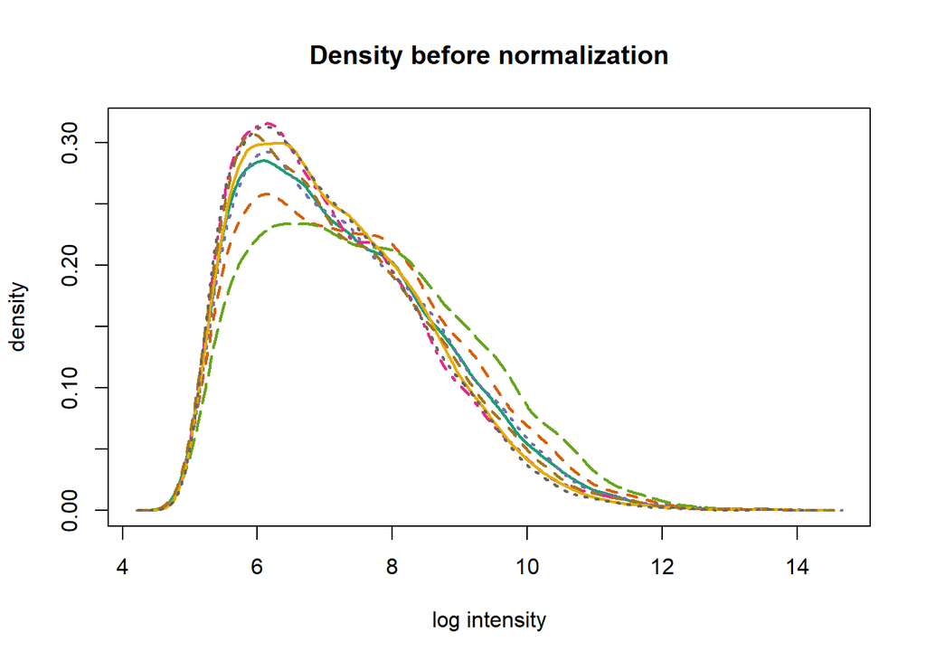

```r
hist(raw_data,lwd=2,xlab='log intensity', which='pm', main="Density before normalization")
```

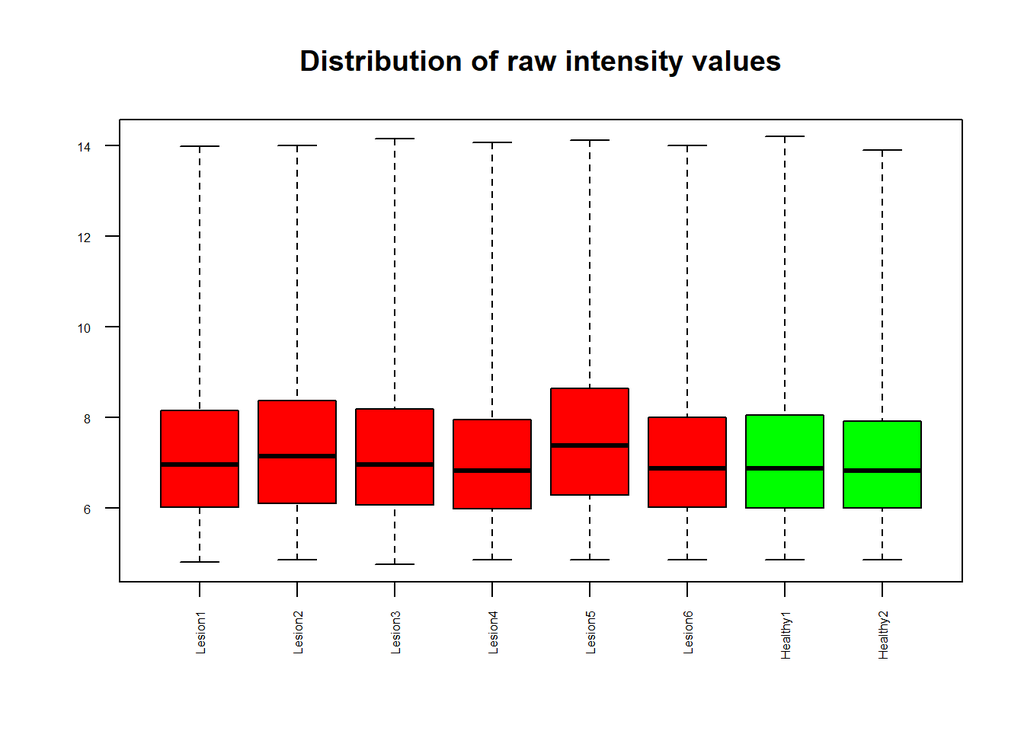

```r
boxplot(raw_data, cex.axis=0.5, las=2, which="all", col=c(rep("red", 6), rep("green", 2)), main="Distribution of raw intensity values")
```

```r
arrayQualityMetrics(raw_data, outdir = "../results_mrna/raw_data_2", force = TRUE)
res <- "../results_mrna/raw_data_2/index.html"
tables <- readHTMLTable(res)
table_QC<-tables[[1]]
knitr::kable(table_QC)
```

|  | array | sampleNames | *1 | *2 | *3 | Group | ShortName |
| --- | --- | --- | --- | --- | --- | --- | --- |
|  | 1 | Lesion1 |  |  |  | Lesion | Lesion1 |
|  | 2 | Lesion2 |  |  |  | Lesion | Lesion2 |
|  | 3 | Lesion3 |  |  |  | Lesion | Lesion3 |
|  | 4 | Lesion4 |  |  |  | Lesion | Lesion4 |
|  | 5 | Lesion5 | x | x | x | Lesion | Lesion5 |
|  | 6 | Lesion6 |  |  |  | Lesion | Lesion6 |
|  | 7 | Healthy1 |  |  |  | Healthy | Healthy1 |
|  | 8 | Healthy2 |  |  |  | Healthy | Healthy2 |

# Normalización de los datos

A continuación, se normalizan los datos mediante el método RMA para corregir la variabilidad técnica entre las distintas muestras. En este método, primero se corrige el background o ruido de fondo ajustando las intensidades de las sondas, seguido de la normalización por cuantiles y la *summarization* por mediana para cada gen.

```r
norm_data <- oligo::rma(raw_data) #RMA
```

```
## Background correcting
## Normalizing
## Calculating Expression
```

# Control de calidad posterior a la normalización

Se repite el análisis de calidad para observar si hay algún cambio en la identificación de outliers y se realiza un Relative Log Expression (RLE) plot para comprobar que la normalización se ha realizado satisfactoriamente.

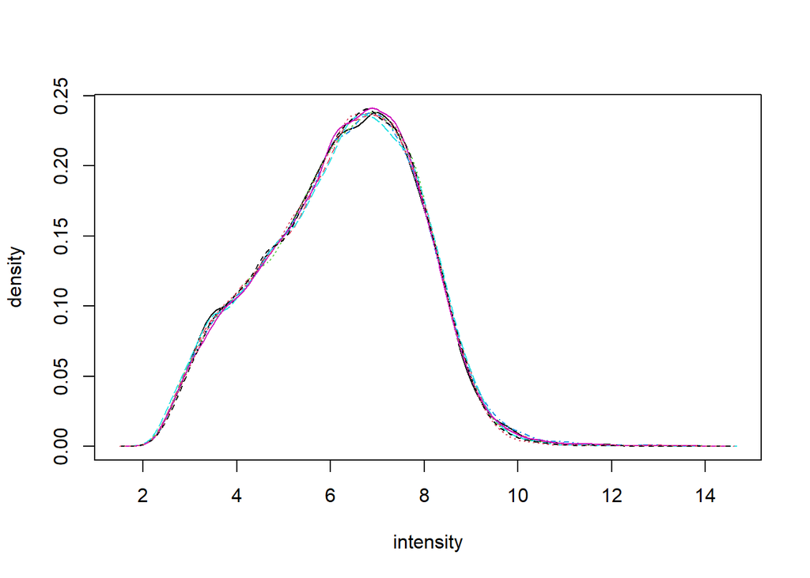

```r
hist(norm_data)
```

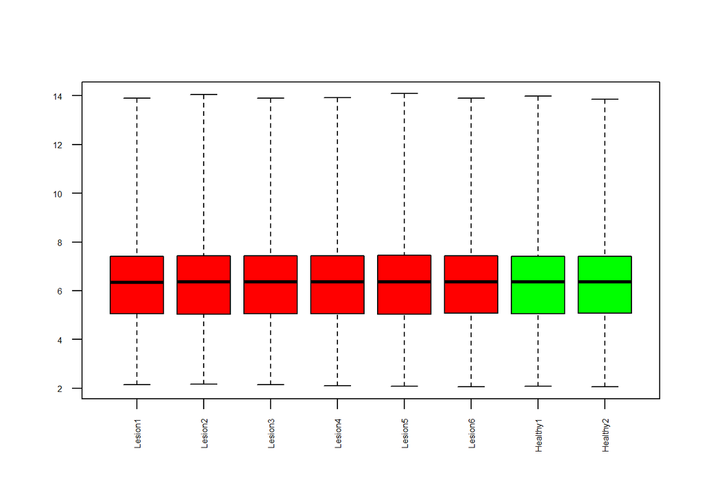

```r
boxplot(norm_data, cex.axis=0.5, las=2,  which="all", col = c(rep("red", 6), rep("green", 2), main="Distribution of norm intensity values"))
```

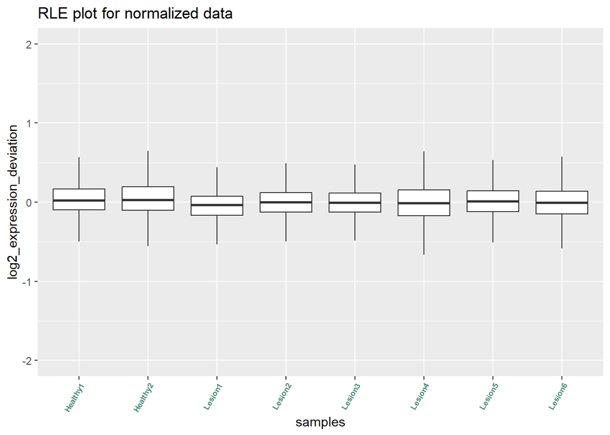

```r
expr_data <- exprs(norm_data)
RLE_plot(expr_data,"RLE plot for normalized data")
```

```r
arrayQualityMetrics(norm_data, outdir= "../results_mrna/norm_data_2", force = TRUE)
res <- "../results_mrna/norm_data_2/index.html"
tables <- readHTMLTable(res)
table_QC<-tables[[1]]
knitr::kable(table_QC)
```

|  | array | sampleNames | *1 | *2 | *3 | Group | ShortName |
| --- | --- | --- | --- | --- | --- | --- | --- |
|  | 1 | Lesion1 |  |  |  | Lesion | Lesion1 |
|  | 2 | Lesion2 |  |  |  | Lesion | Lesion2 |
|  | 3 | Lesion3 |  |  |  | Lesion | Lesion3 |
|  | 4 | Lesion4 |  |  |  | Lesion | Lesion4 |
|  | 5 | Lesion5 |  |  |  | Lesion | Lesion5 |
|  | 6 | Lesion6 |  |  |  | Lesion | Lesion6 |
|  | 7 | Healthy1 |  |  |  | Healthy | Healthy1 |
|  | 8 | Healthy2 |  |  |  | Healthy | Healthy2 |

Después de la normalización, se puede observar que todas las muestras se encuentran dentro de los mismos rangos de expresión, indicando que el proceso de normalización se ha realizado correctamente.

# Análisis exploratorio

Finalmente, se visualiza la agrupación de las muestras mediante un análisis de componentes principales (PCA) y un análisis de clustering según las distancias entre las muestras normalizadas.

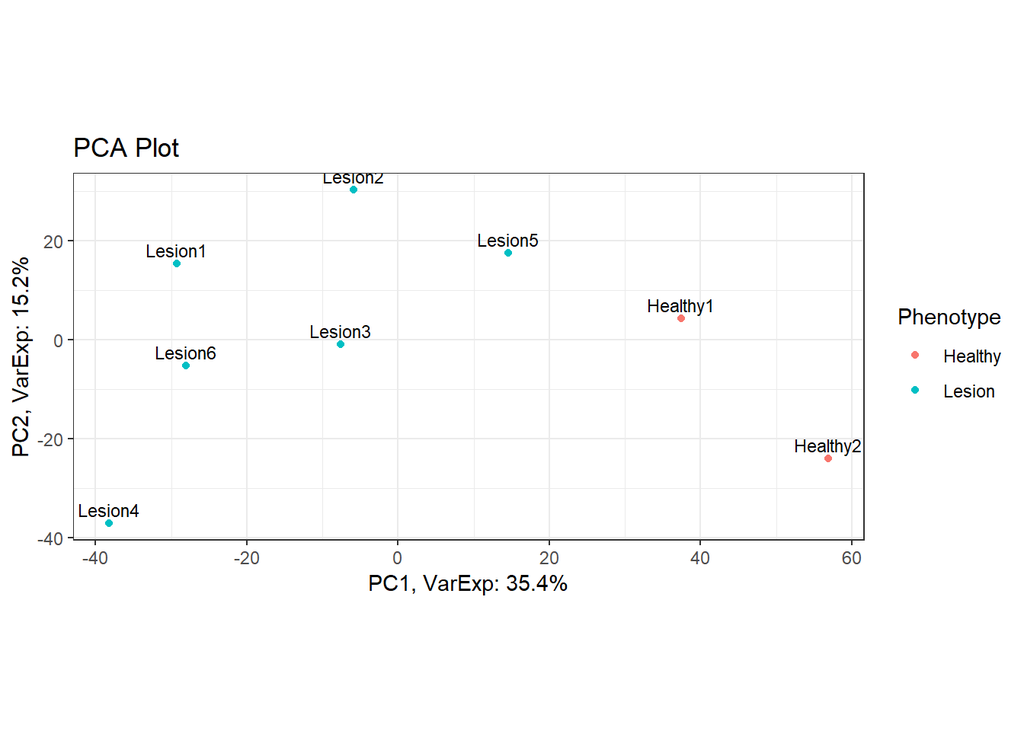

```r
groups <- pData(norm_data)$Group
names <- pData(norm_data)$ShortName
PCA_plot(expr_data, groups, names)
```

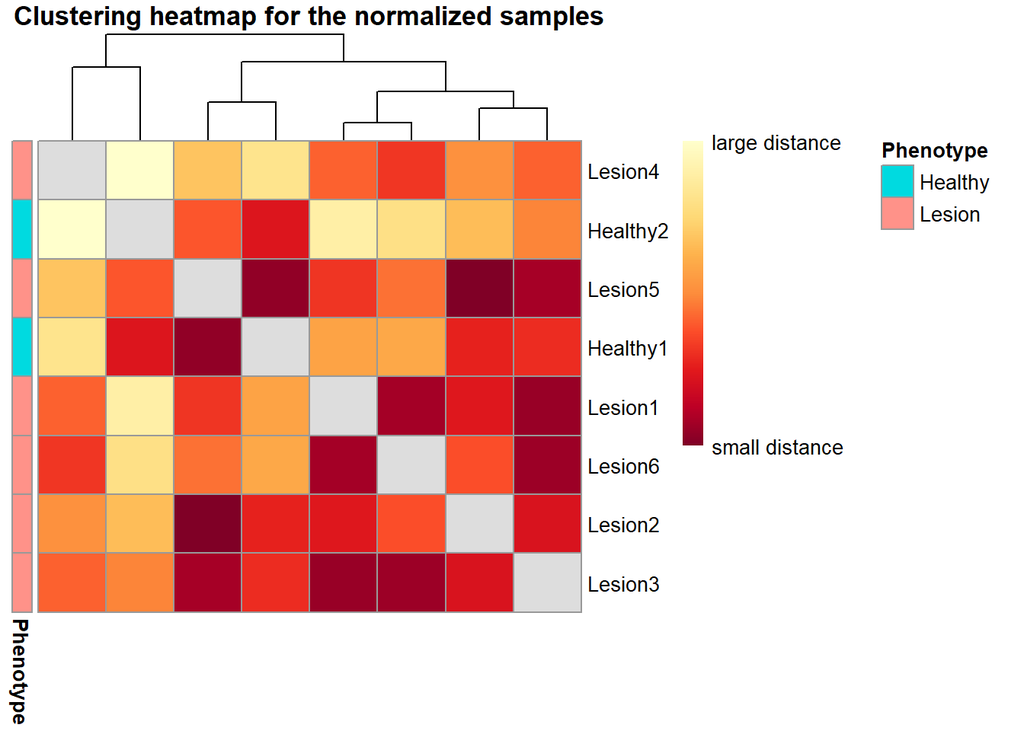

```r
annotation_for_heatmap <-
  data.frame(Phenotype = groups)

row.names(annotation_for_heatmap) <- row.names(pData(norm_data))

dists <- as.matrix(dist(t(expr_data), method = "manhattan"))

rownames(dists) <- row.names(pData(norm_data))
hmcol <- rev(colorRampPalette(RColorBrewer::brewer.pal(9, "YlOrRd"))(255))
colnames(dists) <- NULL
diag(dists) <- NA

ann_colors <- list(
  sample_names = c(wt = "chartreuse4", gipz = "burlywood3")
                   )
set.seed(123)
pheatmap(dists, col = (hmcol),
         annotation_row = annotation_for_heatmap,
         annotation_colors = ann_colors,
         legend = TRUE,
         treeheight_row = 0,
         legend_breaks = c(min(dists, na.rm = TRUE),
                         max(dists, na.rm = TRUE)),
         legend_labels = (c("small distance", "large distance")),
         main = "Clustering heatmap for the normalized samples")
```

# Análisis de expresión diferencial

## Filtrado de los genes

En este apartado se valora realizar un filtrado de genes según su nivel de expresión detectado en las distintas muestras. Se eliminan primero aquellos genes sin anotación (sin Gene Symbol) y posteriormente, se realiza un filtrado de genes basado en su mediana de expresión. Para ello, se utiliza un umbral que elimina los genes cuya mediana de expresión sea inferior al 5% más bajo de todas las medianas de expresión. Este valor de umbral se determina mediante un histograma con las medianas de expresión, identificando un punto de corte adecuado para maximizar la calidad de los datos sin perder información relevante. Cabe destacar que, al tratarse de RNA procedente de vesículas extracelulares, es posible que al aplicar este filtro se pierdan genes relevantes, ya que estas partículas contienen una cantidad más limitada de mRNA comparado con otro tipo de muestras. Por ello, el filtrado aplicado es un filtrado conservador.

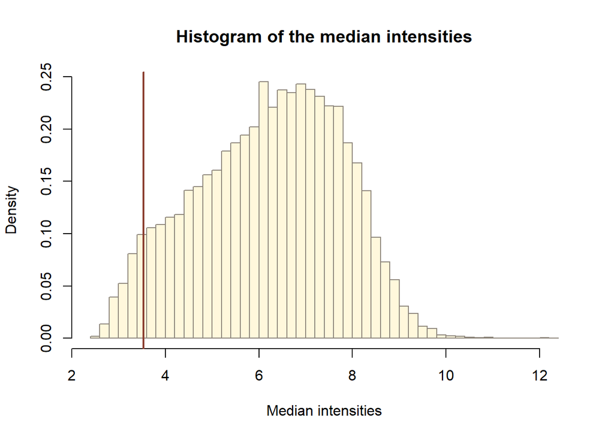

```r
ann_data <- annotateEset(norm_data, pd.clariom.s.human)

ann_data<-ann_data[!is.na(ann_data@featureData@data$SYMBOL),] #remove genes without annotation
#dim(ann_data)

medians <- rowMedians(Biobase::exprs(ann_data)) #calculate median expression of each gene
names(medians) <- rownames(Biobase::exprs(ann_data)) #keep gene names
threshold <- quantile(medians, 0.05)
hist_res <- hist(medians, 50, col = "cornsilk1", freq = FALSE,
            main = "Histogram of the median intensities",
            border = "antiquewhite4",
            xlab = "Median intensities")
abline(v = threshold, col = "coral4", lwd = 2)
```

```r
sorted_genes <- sort(medians) #sort all genes by median
num_genes_to_filter <- floor(0.05 * length(medians))
low_expression_genes <- names(sorted_genes)[1:num_genes_to_filter] #5% least expressed genes
filtered_data <- ann_data[!rownames(ann_data) %in% low_expression_genes, ]
```

# Análisis de expresión diferencial

```r
group <- factor(pData(filtered_data)$Group)
design <- model.matrix(~0 + group)
colnames(design) <- levels(group)
rownames(design) <- pData(filtered_data)$ShortName
print(design)
```

```
##          Healthy Lesion
## Lesion1        0      1
## Lesion2        0      1
## Lesion3        0      1
## Lesion4        0      1
## Lesion5        0      1
## Lesion6        0      1
## Healthy1       1      0
## Healthy2       1      0
## attr(,"assign")
## [1] 1 1
## attr(,"contrasts")
## attr(,"contrasts")$group
## [1] "contr.treatment"
```

```r
contrast.matrix <- makeContrasts(LvsH = Lesion - Healthy, levels = design)

fit <- lmFit(filtered_data, design)
fit.main <- contrasts.fit(fit, contrast.matrix)
fit.main <- eBayes(fit.main)

tab_all = topTable(fit.main, coef="LvsH", number=Inf, adjust.method="fdr")

topTab_1.5<- topTable(fit.main, number = nrow(fit.main), coef = "LvsH",  lfc = 0.585, p.value = 0.05)
dim(topTab_1.5)
```

```
## [1] 122  10
```

```r
head(topTab_1.5)
```

```
##                             PROBEID           ID SYMBOL
## TC0800011239.hg.1 TC0800011239.hg.1    NM_004374  COX6C
## TC0100015899.hg.1 TC0100015899.hg.1 NM_001043351   TPM3
## TC1000010265.hg.1 TC1000010265.hg.1    NM_002211  ITGB1
## TC0600013719.hg.1 TC0600013719.hg.1 NM_001291602 DYNLT1
## TC0300009459.hg.1 TC0300009459.hg.1    NM_014373 GPR160
## TC0100007268.hg.1 TC0100007268.hg.1 NM_001039802  CDC42
##                                            GENENAME    logFC  AveExpr         t
## TC0800011239.hg.1  cytochrome c oxidase subunit VIc 2.453425 7.450193 12.846755
## TC0100015899.hg.1                     tropomyosin 3 2.155753 7.847869  9.739265
## TC1000010265.hg.1                   integrin beta 1 2.452503 6.980951  9.111265
## TC0600013719.hg.1 dynein, light chain, Tctex-type 1 1.872660 7.191507  9.061239
## TC0300009459.hg.1    G protein-coupled receptor 160 1.977375 6.672172  8.883320
## TC0100007268.hg.1            cell division cycle 42 1.813157 6.598902  8.461166
##                        P.Value    adj.P.Val        B
## TC0800011239.hg.1 2.153780e-08 0.0004388541 8.574486
## TC0100015899.hg.1 4.601592e-07 0.0046881020 6.306685
## TC1000010265.hg.1 9.395496e-07 0.0050081436 5.730953
## TC0600013719.hg.1 9.961367e-07 0.0050081436 5.683082
## TC0300009459.hg.1 1.228932e-06 0.0050081436 5.510330
## TC0100007268.hg.1 2.049136e-06 0.0063587499 5.084399
```

```r
datatable(topTab_1.5,caption = "DEG Lesion vs Healthy FC 1.5")
```

|  | PROBEID | ID | SYMBOL | GENENAME | logFC | AveExpr | t | P.Value | adj.P.Val | B |
| --- | --- | --- | --- | --- | --- | --- | --- | --- | --- | --- |
| TC0800011239.hg.1 | TC0800011239.hg.1 | NM_004374 | COX6C | cytochrome c oxidase subunit VIc | 2.453424883674749 | 7.450193009399811 | 12.84675510418289 | 2.153779599762116e-08 | 0.0004388541312475287 | 8.574486004711593 |
| TC0100015899.hg.1 | TC0100015899.hg.1 | NM_001043351 | TPM3 | tropomyosin 3 | 2.155753218188716 | 7.847868753397663 | 9.739264733482715 | 4.601592103848139e-07 | 0.004688102035400484 | 6.306684624723673 |
| TC1000010265.hg.1 | TC1000010265.hg.1 | NM_002211 | ITGB1 | integrin beta 1 | 2.452503036153189 | 6.98095137089454 | 9.11126495135587 | 9.395495718468776e-07 | 0.005008143607412788 | 5.730953036875489 |
| TC0600013719.hg.1 | TC0600013719.hg.1 | NM_001291602 | DYNLT1 | dynein, light chain, Tctex-type 1 | 1.872660469894481 | 7.191507418565846 | 9.061239242808197 | 9.961367482998308e-07 | 0.005008143607412788 | 5.683081827043315 |
| TC0300009459.hg.1 | TC0300009459.hg.1 | NM_014373 | GPR160 | G protein-coupled receptor 160 | 1.977375288118509 | 6.672171581585108 | 8.883320109851832 | 1.228931980617587e-06 | 0.005008143607412788 | 5.51033001041208 |
| TC0100007268.hg.1 | TC0100007268.hg.1 | NM_001039802 | CDC42 | cell division cycle 42 | 1.813156861005265 | 6.598902477708152 | 8.461165685142191 | 2.049136245848605e-06 | 0.006358749918575496 | 5.084399312613158 |
| TC0100013588.hg.1 | TC0100013588.hg.1 | NM_001195100 | PTP4A2 | protein tyrosine phosphatase type IVA, member 2 | 1.587016040936463 | 6.070502599801422 | 8.39922819011396 | 2.212252369844715e-06 | 0.006358749918575496 | 5.019954870102021 |
| TC0800012433.hg.1 | TC0800012433.hg.1 | NM_001025252 | TPD52 | tumor protein D52 | 2.004593541597977 | 6.796295325837983 | 8.242012666478281 | 2.692025799442791e-06 | 0.006358749918575496 | 4.854070537094877 |
| TC0200012735.hg.1 | TC0200012735.hg.1 | USP34.vcAug10-unspliced | USP34 | Transcript Identified by AceView, Entrez Gene ID(s) 9736 | 1.528602628542161 | 6.548035491442234 | 8.208330366743468 | 2.808635123045714e-06 | 0.006358749918575496 | 4.818096241230446 |
| TC0700013602.hg.1 | TC0700013602.hg.1 | NM_001097615 | POLR2J3 | polymerase (RNA) II (DNA directed) polypeptide J3 | 1.445387824806652 | 7.169028827044534 | 7.969038927767257 | 3.809907987140694e-06 | 0.007069518158369452 | 4.558026819059295 |

[output cut: 112 more lines]

[figure not shown]

```r
#Volcano plot
EnhancedVolcano(
  tab_all,
  lab = tab_all$SYMBOL,
  x = 'logFC',
  y = 'P.Value',
  xlab = 'Log2 Fold Change',
  ylab = '-Log10 P-Value',
  pCutoff = 0.05,
  FCcutoff = 0.585,
  pointSize = 2.0,
  labSize = 3.0,
  col = c('grey30', 'forestgreen', 'royalblue', 'red2'),
  colAlpha = 0.6,
  legendPosition = 'right',
  legendLabSize = 10,
  legendIconSize = 3.0,
  title = "Volcano plot FC 1.5")
```

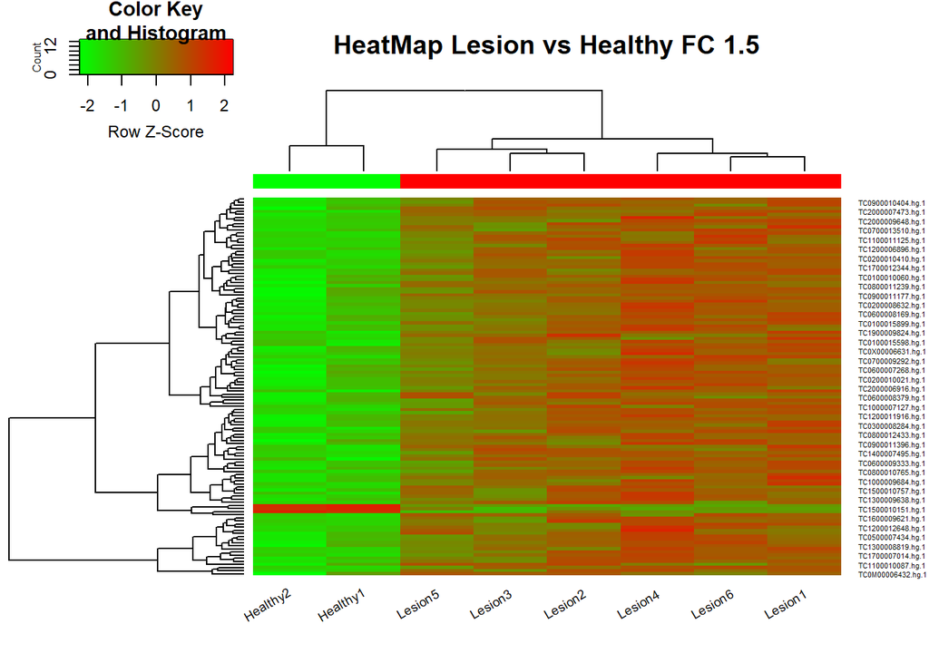

```r
#Heatmap

selectedRows <- rownames(filtered_data) %in% rownames(topTab_1.5)
selectedData <- filtered_data[selectedRows, ]
selectedData <- as.matrix(selectedData)
my_palette <- colorRampPalette(c("green", "red"))(n = 299)
heatmap.2(selectedData, Rowv = TRUE, Colv = TRUE, main = "HeatMap Lesion vs Healthy FC 1.5",
    scale = "row", col = my_palette, sepcolor = "white", sepwidth = c(0.05, 0.05),
    cexRow = 0.5, cexCol = 0.9, key = TRUE, keysize = 1.5, density.info = "histogram",
    ColSideColors = c(rep("red", 6), rep("green", 2)), tracecol = NULL, srtCol = 30)
```

# Análisis de enriquecimiento (ORA)

Tras identificar los DEGs, se realiza un análisis de enriquecimiento funcional para explorar las vías y procesos más característicos asociados con estos genes, buscando una interpretación biológica de los resultados.

Para este análisis, se utiliza el paquete `clusterProfiler` (@Yu2012) que permite realizar estudios de enriquecimiento funcional interrogando bases de datos como GO (Gene Ontology), para la clasificación de los genes según procesos biológicos (BP), componentes celulares (CC) y funciones moleculares (MF), y Reactome o KEGG para identificar rutas metabólicas y de señalización enriquecidas (@clusterProfilerGuide). Se usarán los DEG con un Fold change de 1.5. Los resultados se visualizan mediante distintos gráficos, mostrando los términos o vías enriquecidas, su significancia y la relación entre ellas.

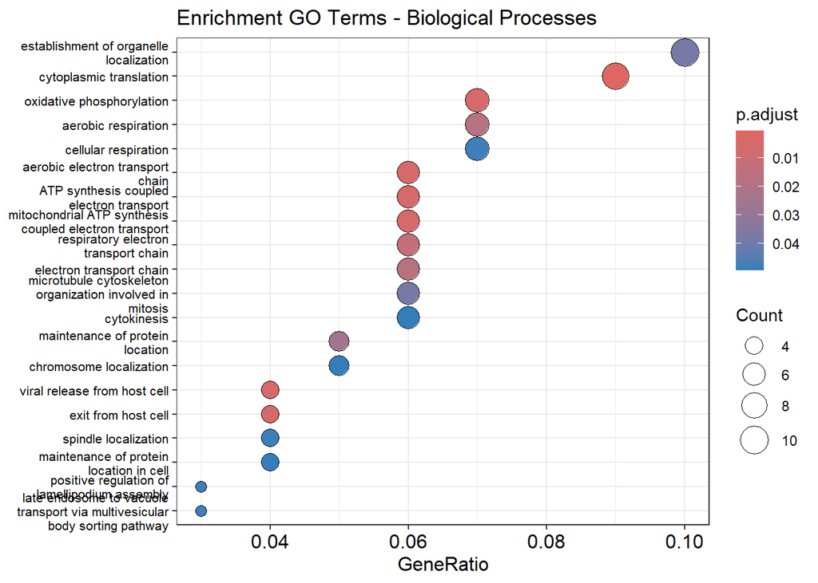

```r
gene_symbols <- unique(topTab_1.5$SYMBOL)
go_enrich_BP <- enrichGO(gene = gene_symbols,
                      OrgDb = org.Hs.eg.db,
                      keyType = "SYMBOL",
                      ont = "BP",  # Biological Process
                      pAdjustMethod = "fdr",
                      pvalueCutoff = 0.05,
                      qvalueCutoff = 0.05)

clusterProfiler::dotplot(go_enrich_BP, showCategory = 20) + ggtitle("Enrichment GO Terms - Biological Processes") + theme(axis.text.y = element_text(size = 8))
```

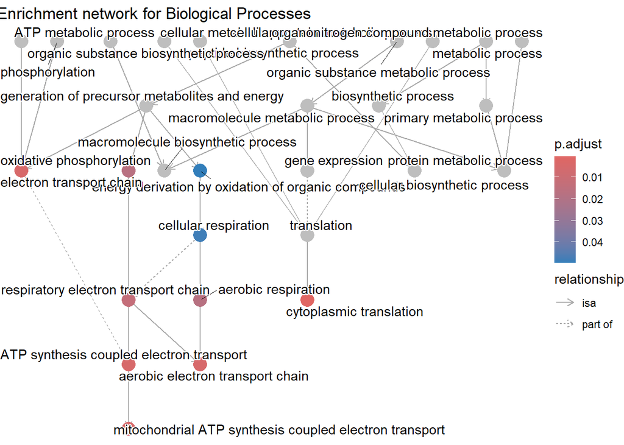

```r
goplot(go_enrich_BP, showCategory=5) + ggtitle("Enrichment network for Biological Processes")
```

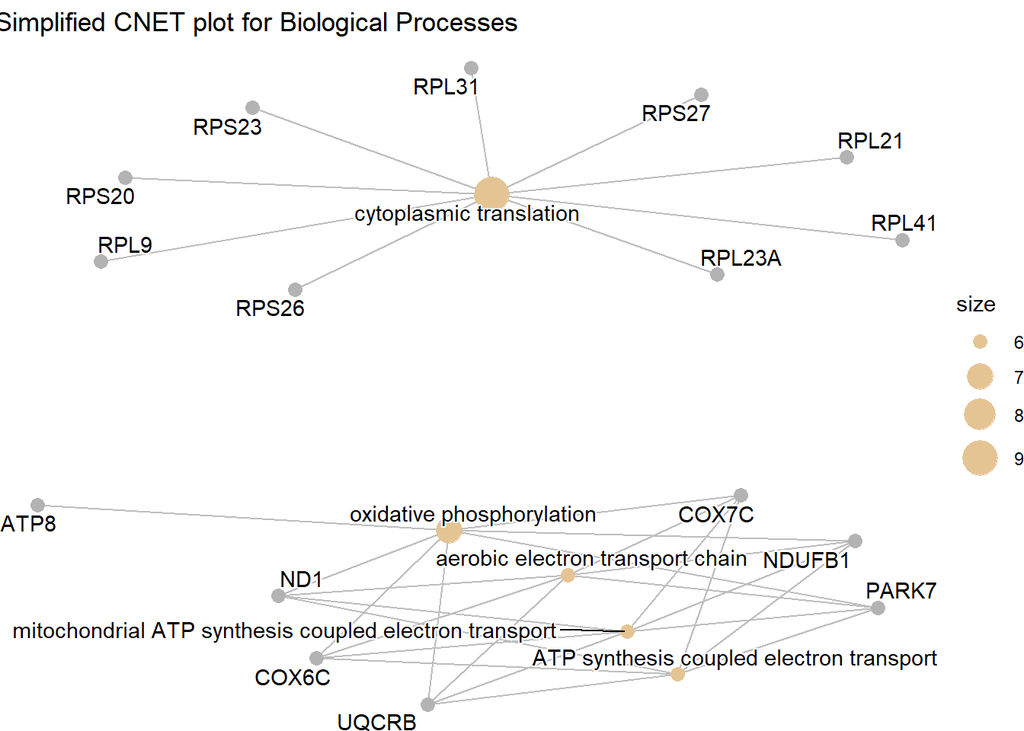

```r
s_BP <- clusterProfiler::simplify(go_enrich_BP)

cnetplot(s_BP) + ggtitle("Simplified CNET plot for Biological Processes")
```

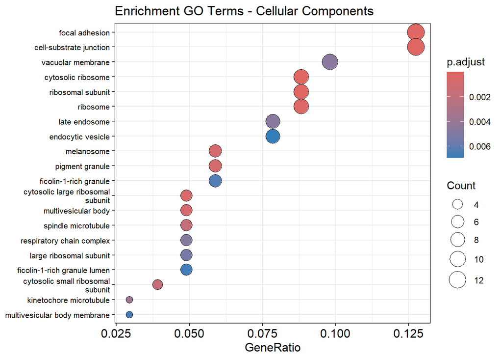

```r
go_enrich_CC <- enrichGO(gene = gene_symbols,
                      OrgDb = org.Hs.eg.db,
                      keyType = "SYMBOL",
                      ont = "CC",  # Cellular Component
                      pAdjustMethod = "fdr",
                      pvalueCutoff = 0.05,
                      qvalueCutoff = 0.05)

clusterProfiler::dotplot(go_enrich_CC, showCategory = 20) + ggtitle("Enrichment GO Terms - Cellular Components") + theme(axis.text.y = element_text(size = 8))
```

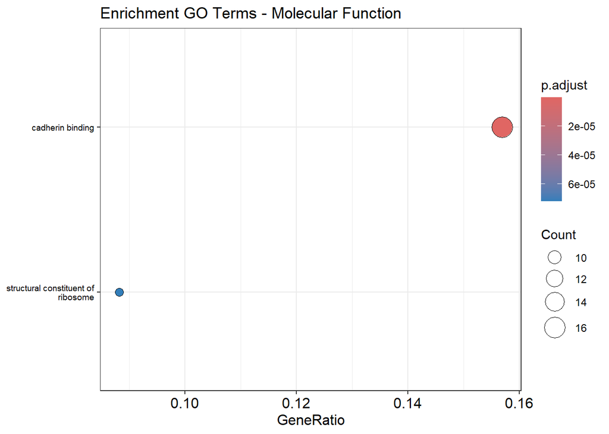

```r
go_enrich_MF <- enrichGO(gene = gene_symbols,
                      OrgDb = org.Hs.eg.db,
                      keyType = "SYMBOL",
                      ont = "MF",  # Molecular Function
                      pAdjustMethod = "fdr",
                      pvalueCutoff = 0.05,
                      qvalueCutoff = 0.05)

clusterProfiler::dotplot(go_enrich_MF, showCategory = 20) + ggtitle("Enrichment GO Terms - Molecular Function") + theme(axis.text.y = element_text(size = 7))
```

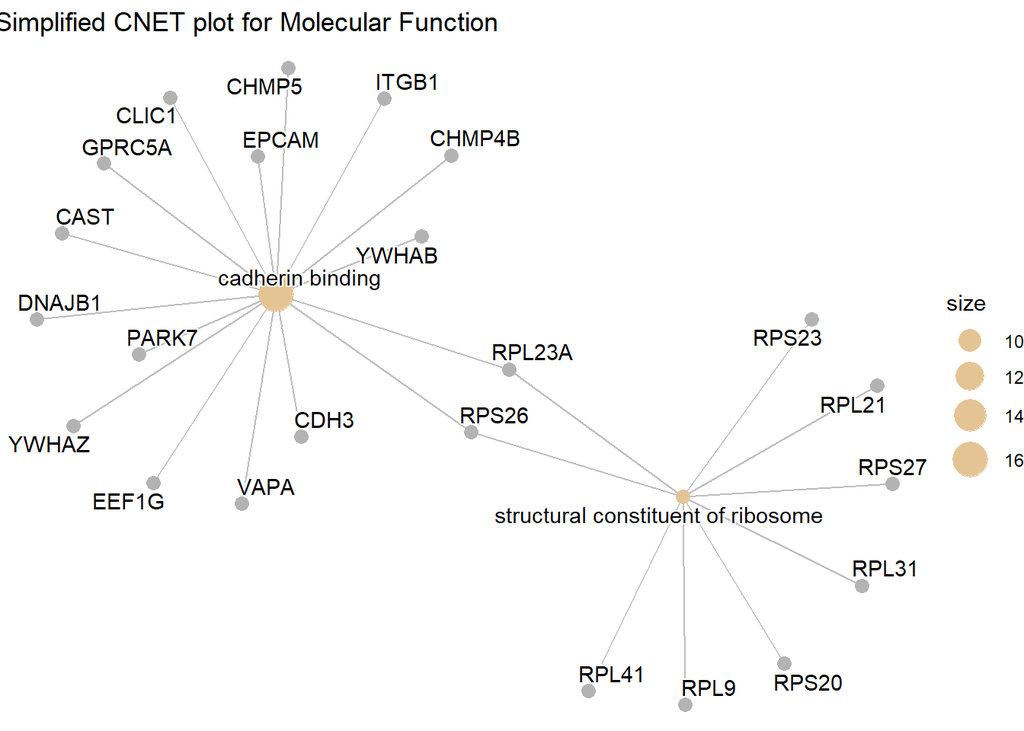

```r
s_MF <- clusterProfiler::simplify(go_enrich_MF)

cnetplot(s_MF) + ggtitle("Simplified CNET plot for Molecular Function")
```

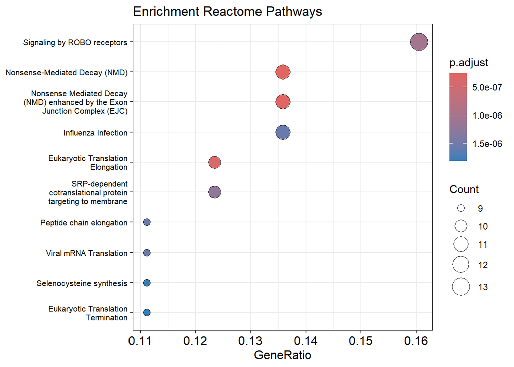

```r
#get ENTREZ IDs
gene_ids <- bitr(gene_symbols, fromType="SYMBOL",
                              toType="ENTREZID",
                              OrgDb="org.Hs.eg.db")

entrez_ids <- gene_ids$ENTREZID

reactome_enrich <- enrichPathway(gene = entrez_ids,
                                 organism = "human",
                                 pAdjustMethod = "fdr",
                                 pvalueCutoff = 0.05,
                                 qvalueCutoff = 0.05)

clusterProfiler::dotplot(reactome_enrich, showCategory = 10) + ggtitle("Enrichment Reactome Pathways") + theme(axis.text.y = element_text(size = 8))
```

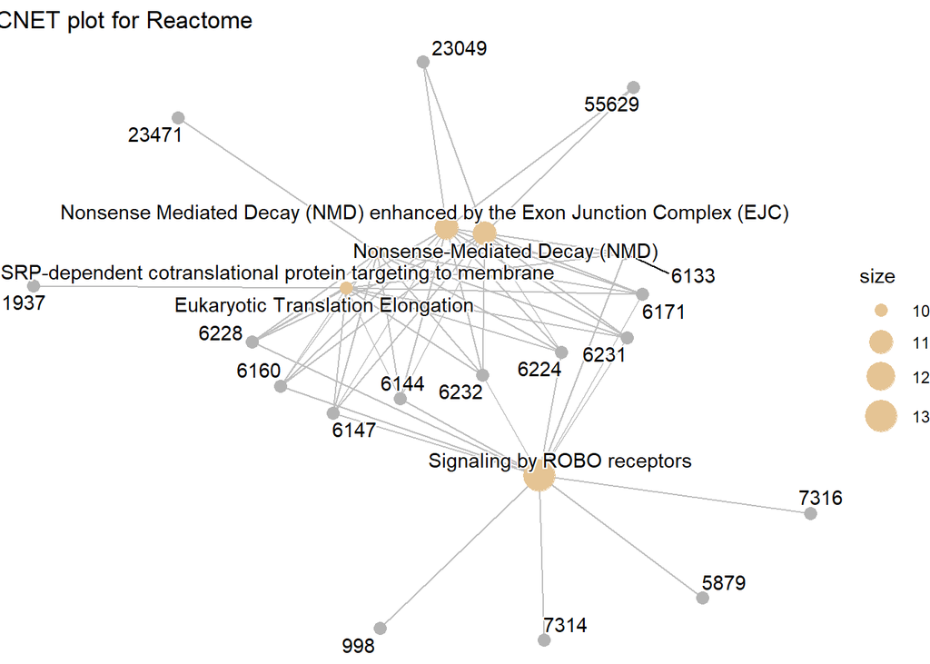

```r
cnetplot(reactome_enrich) + ggtitle("CNET plot for Reactome")
```

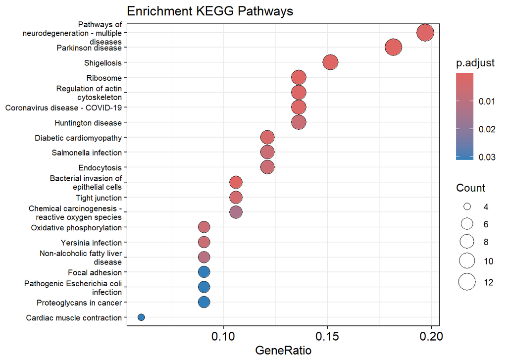

```r
KEGG_genes <- enrichKEGG(gene = entrez_ids, organism = "hsa", pvalueCutoff = 0.05)

clusterProfiler::dotplot(KEGG_genes, showCategory = 20) + ggtitle("Enrichment KEGG Pathways") + theme(axis.text.y = element_text(size = 8))
```

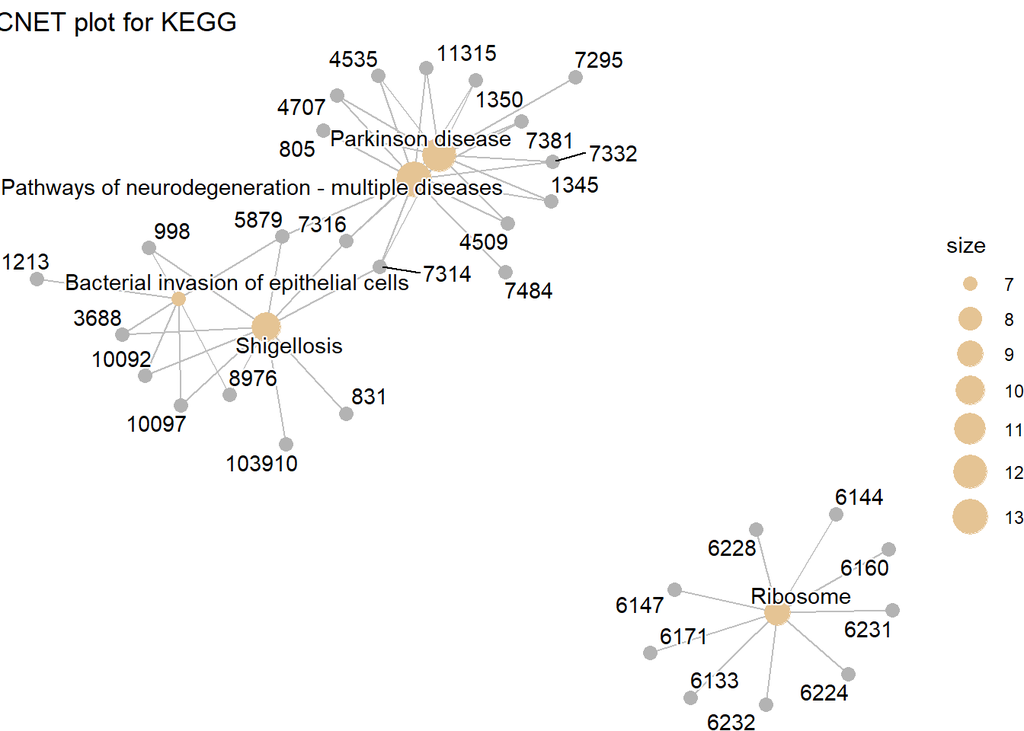

```r
cnetplot(KEGG_genes) + ggtitle("CNET plot for KEGG")
```

# Análisis de enriquecimiento (GSEA)

Finalmente, se realiza un Gene Set Enrichment Analysis o GSEA (@Subramanian2005) con las mismas bases de datos usadas anteriormente y se utiliza igualmente el paquete `clusterProfiler` (@Yu2012). Este análisis permite evaluar si existen diferencias significativas en conjuntos de genes previamente definidos. El GSEA toma como input una lista ordenada de todos los genes identificados. En este caso, los genes se han ordenado por Fold change y por el score calculado como el producto del Fold change y el logaritmo en base 10 del p-valor, para ordenar los genes según su magnitud de cambio y significancia. Los resultados se visualizan mediante distintos gráficos, mostrando los términos o vías enriquecidas y los Normalized Enrichment Scores. Sin embargo, solo se han encontrado términos enriquecidos ordenando únicamente por Fold change, por lo que aquí se presenta solo este último caso. Además, solo se han identificado vías enriquecidas con los términos GO, pero no se han detectado vías significativamente enriquecidas en las bases de datos Reactome ni KEGG.

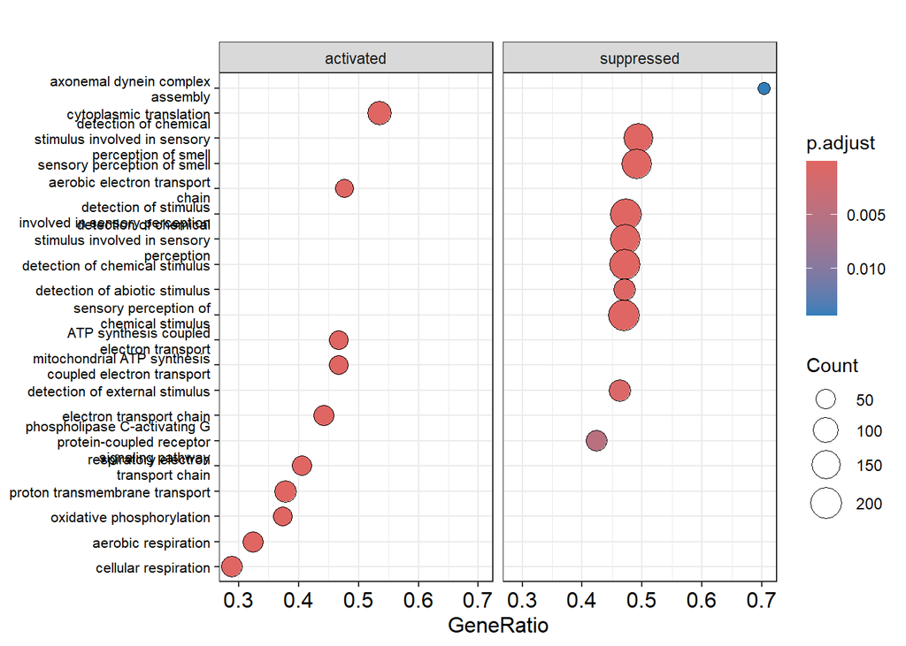

```r
gene_list <- tab_all$logFC
names(gene_list) <- tab_all$SYMBOL
gene_list <- gene_list[!duplicated(names(gene_list))]
GSEA_data <- sort(gene_list, decreasing = TRUE)

set.seed(123)

gsea_goBP <- gseGO(geneList = GSEA_data,
              OrgDb = org.Hs.eg.db,
              ont = "BP",
              keyType = "SYMBOL",
              seed=TRUE)

clusterProfiler::dotplot(gsea_goBP, showCategory=10, split=".sign") + facet_grid(.~.sign) + theme(axis.text.y = element_text(size = 8))
```

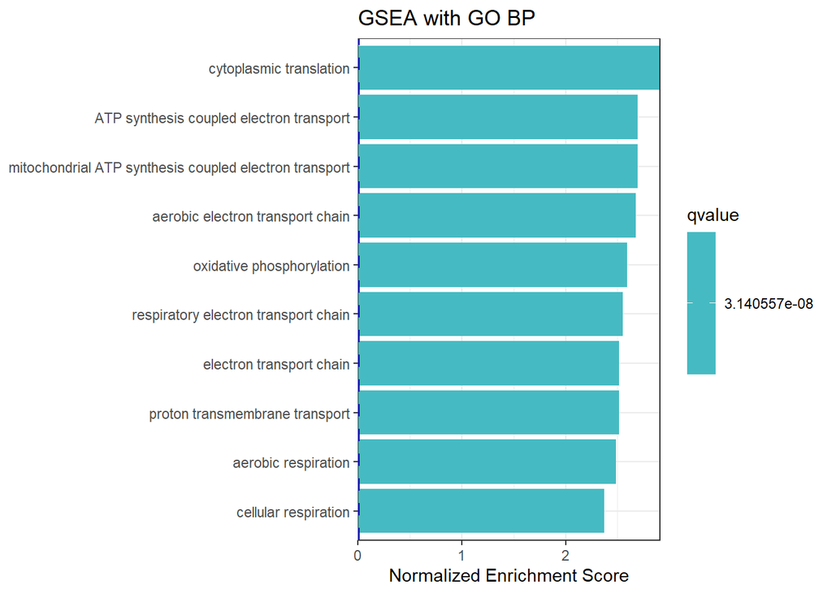

```r
gsea_goBP_filter <- filter(gsea_goBP,NES > 1.95 | NES < -2)

ggplot(gsea_goBP_filter, showCategory=10, aes(NES, fct_reorder(Description, NES),
fill=qvalue)) +
  geom_col() +
  geom_vline(xintercept=0, linetype="dashed", color="blue",size=1)+
  scale_fill_gradientn(colours=c("#b3eebe","#46bac2", "#371ea3"),
                       guide=guide_colorbar(reverse=TRUE))+
  scale_x_continuous(expand=c(0,0))+
  theme_bw() +
  #theme(text=element_text(size=8))+
  xlab("Normalized Enrichment Score") +
  ylab(NULL) +
  ggtitle("GSEA with GO BP")
```

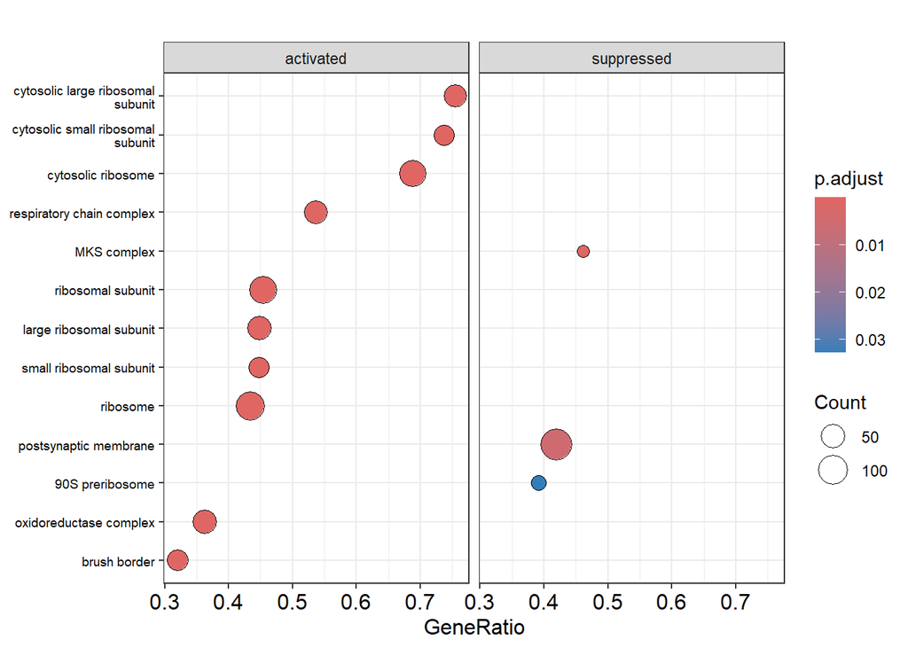

```r
gsea_goCC <- gseGO(geneList = GSEA_data,
              OrgDb = org.Hs.eg.db,
              ont = "CC",
              keyType = "SYMBOL",
              seed=TRUE)

clusterProfiler::dotplot(gsea_goCC, showCategory=10, split=".sign") + facet_grid(.~.sign) + theme(axis.text.y = element_text(size = 7))
```

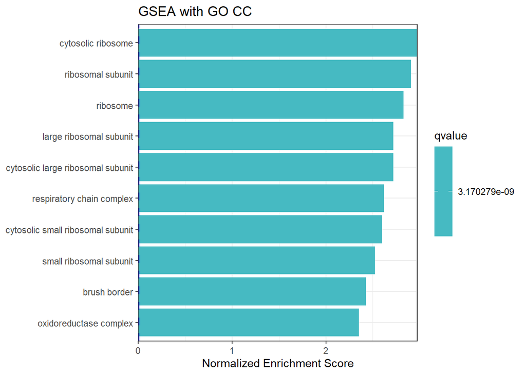

```r
gsea_goCC_filter <- filter(gsea_goCC,NES > 1.95 | NES < -2)

ggplot(gsea_goCC_filter, showCategory=10, aes(NES, fct_reorder(Description, NES),
fill=qvalue)) +
  geom_col() +
  geom_vline(xintercept=0, linetype="dashed", color="blue",size=1)+
  scale_fill_gradientn(colours=c("#b3eebe","#46bac2", "#371ea3"),
                       guide=guide_colorbar(reverse=TRUE))+
  scale_x_continuous(expand=c(0,0))+
  theme_bw() +
  #theme(text=element_text(size=8))+
  xlab("Normalized Enrichment Score") +
  ylab(NULL) +
  ggtitle("GSEA with GO CC")
```

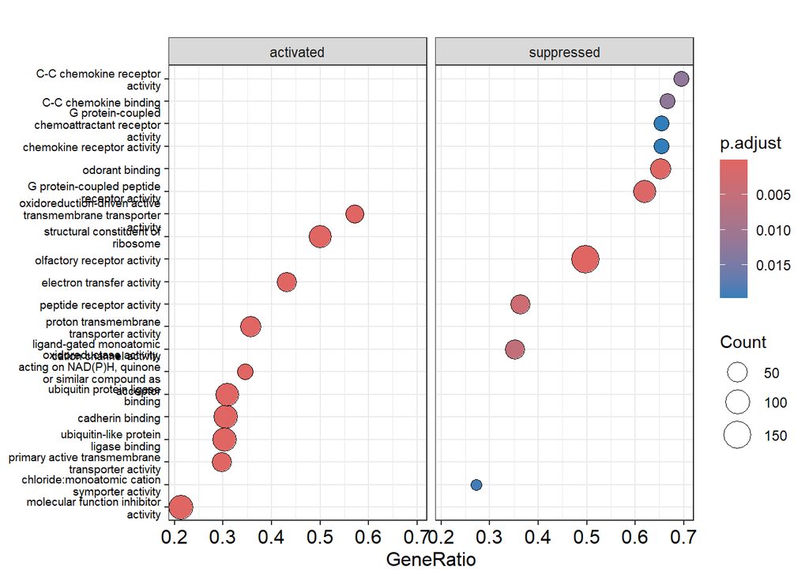

```r
gsea_goMF <- gseGO(geneList = GSEA_data,
              OrgDb = org.Hs.eg.db,
              ont = "MF",
              keyType = "SYMBOL",
              seed=TRUE)

clusterProfiler::dotplot(gsea_goMF, showCategory=10, split=".sign") + facet_grid(.~.sign) + theme(axis.text.y = element_text(size = 7))
```

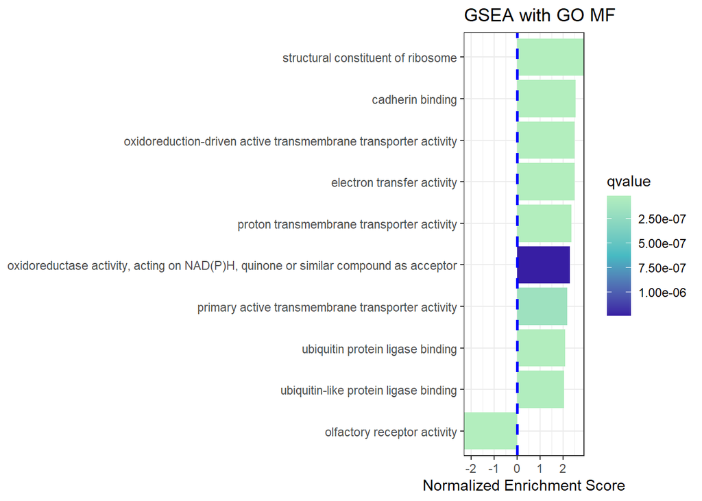

```r
gsea_goMF_filter <- filter(gsea_goMF,NES > 1.95 | NES < -2)

ggplot(gsea_goMF_filter, showCategory=10, aes(NES, fct_reorder(Description, NES),
fill=qvalue)) +
  geom_col() +
  geom_vline(xintercept=0, linetype="dashed", color="blue",size=1)+
  scale_fill_gradientn(colours=c("#b3eebe","#46bac2", "#371ea3"),
                       guide=guide_colorbar(reverse=TRUE))+
  scale_x_continuous(expand=c(0,0))+
  theme_bw() +
  #theme(text=element_text(size=8))+
  xlab("Normalized Enrichment Score") +
  ylab(NULL) +
  ggtitle("GSEA with GO MF")
```

```r
mapped_entrez <- gene_ids$ENTREZID[match(names(GSEA_data), gene_ids$SYMBOL)]
GSEA_data_entrez <- setNames(GSEA_data, mapped_entrez)
GSEA_data_entrez <- GSEA_data_entrez[!is.na(names(GSEA_data_entrez))]
GSEA_data_entrez <- sort(GSEA_data_entrez, decreasing = TRUE)


#gsea_R <- gsePathway(geneList = GSEA_data_entrez,
 #             organism="human",
 #            seed=TRUE)

# no term enriched under specific pvalueCutoff...


#gsea_KEGG <- gseKEGG(geneList = GSEA_data_entrez,
  #                  organism = "human",
   #                  keyType = "kegg",
    #                 seed = TRUE)

# no term enriched under specific pvalueCutoff...
```